# Risk Factor Analysis

## Outcome Variable

**Outcome Variable:** whz

## Predictor Variables

**Intervention Variable:** nhh

**Adjustment Set:**

- arm
- W_mage
- meducyrs
- feducyrs
- hhwealth_quart
- W_mhtcm
- W_mwtkg
- W_mbmi
- W_nrooms
- cleanck
- impfloor
- impsan
- safeh20
- delta_W_mage
- delta_meducyrs
- delta_feducyrs
- delta_hhwealth_quart
- delta_W_mhtcm
- delta_W_mwtkg
- delta_W_mbmi
- delta_W_nrooms
- delta_cleanck
- delta_impfloor
- delta_impsan
- delta_safeh20

## Stratifying Variables

The analysis was stratified on these variable(s):

- agecat
- studyid
- country

## Data Summary

| agecat | studyid | country | nhh | n_cell | n |
| --- | --- | --- | --- | --- | --- |
| Birth | ki1000108-IRC | INDIA | 3 or less | 52 | 343 |
| Birth | ki1000108-IRC | INDIA | 4-5 | 131 | 343 |
| Birth | ki1000108-IRC | INDIA | 6-7 | 84 | 343 |
| Birth | ki1000108-IRC | INDIA | 8+ | 76 | 343 |
| Birth | ki1017093-NIH-Birth | BANGLADESH | 3 or less | 104 | 575 |
| Birth | ki1017093-NIH-Birth | BANGLADESH | 4-5 | 244 | 575 |
| Birth | ki1017093-NIH-Birth | BANGLADESH | 6-7 | 130 | 575 |
| Birth | ki1017093-NIH-Birth | BANGLADESH | 8+ | 97 | 575 |
| Birth | ki1017093b-PROVIDE | BANGLADESH | 3 or less | 103 | 532 |
| Birth | ki1017093b-PROVIDE | BANGLADESH | 4-5 | 249 | 532 |
| Birth | ki1017093b-PROVIDE | BANGLADESH | 6-7 | 114 | 532 |
| Birth | ki1017093b-PROVIDE | BANGLADESH | 8+ | 66 | 532 |
| Birth | ki1017093c-NIH-Crypto | BANGLADESH | 3 or less | 103 | 707 |
| Birth | ki1017093c-NIH-Crypto | BANGLADESH | 4-5 | 318 | 707 |
| Birth | ki1017093c-NIH-Crypto | BANGLADESH | 6-7 | 167 | 707 |
| Birth | ki1017093c-NIH-Crypto | BANGLADESH | 8+ | 119 | 707 |
| 6 months | ki1000108-IRC | INDIA | 3 or less | 57 | 408 |
| 6 months | ki1000108-IRC | INDIA | 4-5 | 157 | 408 |
| 6 months | ki1000108-IRC | INDIA | 6-7 | 107 | 408 |
| 6 months | ki1000108-IRC | INDIA | 8+ | 87 | 408 |
| 6 months | ki1000304b-SAS-FoodSuppl | INDIA | 3 or less | 33 | 380 |
| 6 months | ki1000304b-SAS-FoodSuppl | INDIA | 4-5 | 166 | 380 |
| 6 months | ki1000304b-SAS-FoodSuppl | INDIA | 6-7 | 115 | 380 |
| 6 months | ki1000304b-SAS-FoodSuppl | INDIA | 8+ | 66 | 380 |
| 6 months | ki1017093-NIH-Birth | BANGLADESH | 3 or less | 95 | 537 |
| 6 months | ki1017093-NIH-Birth | BANGLADESH | 4-5 | 227 | 537 |
| 6 months | ki1017093-NIH-Birth | BANGLADESH | 6-7 | 128 | 537 |
| 6 months | ki1017093-NIH-Birth | BANGLADESH | 8+ | 87 | 537 |
| 6 months | ki1017093b-PROVIDE | BANGLADESH | 3 or less | 105 | 603 |
| 6 months | ki1017093b-PROVIDE | BANGLADESH | 4-5 | 289 | 603 |
| 6 months | ki1017093b-PROVIDE | BANGLADESH | 6-7 | 130 | 603 |
| 6 months | ki1017093b-PROVIDE | BANGLADESH | 8+ | 79 | 603 |
| 6 months | ki1017093c-NIH-Crypto | BANGLADESH | 3 or less | 104 | 715 |
| 6 months | ki1017093c-NIH-Crypto | BANGLADESH | 4-5 | 326 | 715 |
| 6 months | ki1017093c-NIH-Crypto | BANGLADESH | 6-7 | 170 | 715 |
| 6 months | ki1017093c-NIH-Crypto | BANGLADESH | 8+ | 115 | 715 |
| 6 months | ki1148112-LCNI-5 | MALAWI | 3 or less | 224 | 816 |
| 6 months | ki1148112-LCNI-5 | MALAWI | 4-5 | 340 | 816 |
| 6 months | ki1148112-LCNI-5 | MALAWI | 6-7 | 182 | 816 |
| 6 months | ki1148112-LCNI-5 | MALAWI | 8+ | 70 | 816 |
| 24 months | ki1000108-IRC | INDIA | 3 or less | 58 | 409 |
| 24 months | ki1000108-IRC | INDIA | 4-5 | 158 | 409 |
| 24 months | ki1000108-IRC | INDIA | 6-7 | 107 | 409 |
| 24 months | ki1000108-IRC | INDIA | 8+ | 86 | 409 |
| 24 months | ki1017093-NIH-Birth | BANGLADESH | 3 or less | 74 | 428 |
| 24 months | ki1017093-NIH-Birth | BANGLADESH | 4-5 | 184 | 428 |
| 24 months | ki1017093-NIH-Birth | BANGLADESH | 6-7 | 100 | 428 |
| 24 months | ki1017093-NIH-Birth | BANGLADESH | 8+ | 70 | 428 |
| 24 months | ki1017093b-PROVIDE | BANGLADESH | 3 or less | 106 | 579 |
| 24 months | ki1017093b-PROVIDE | BANGLADESH | 4-5 | 273 | 579 |
| 24 months | ki1017093b-PROVIDE | BANGLADESH | 6-7 | 117 | 579 |
| 24 months | ki1017093b-PROVIDE | BANGLADESH | 8+ | 83 | 579 |
| 24 months | ki1017093c-NIH-Crypto | BANGLADESH | 3 or less | 69 | 514 |
| 24 months | ki1017093c-NIH-Crypto | BANGLADESH | 4-5 | 232 | 514 |
| 24 months | ki1017093c-NIH-Crypto | BANGLADESH | 6-7 | 130 | 514 |
| 24 months | ki1017093c-NIH-Crypto | BANGLADESH | 8+ | 83 | 514 |
| 24 months | ki1148112-LCNI-5 | MALAWI | 3 or less | 157 | 558 |
| 24 months | ki1148112-LCNI-5 | MALAWI | 4-5 | 230 | 558 |
| 24 months | ki1148112-LCNI-5 | MALAWI | 6-7 | 123 | 558 |
| 24 months | ki1148112-LCNI-5 | MALAWI | 8+ | 48 | 558 |

The following strata were considered:

- agecat: 24 months, studyid: ki1000108-IRC, country: INDIA
- agecat: 24 months, studyid: ki1017093-NIH-Birth, country: BANGLADESH
- agecat: 24 months, studyid: ki1017093b-PROVIDE, country: BANGLADESH
- agecat: 24 months, studyid: ki1017093c-NIH-Crypto, country: BANGLADESH
- agecat: 24 months, studyid: ki1148112-LCNI-5, country: MALAWI
- agecat: 6 months, studyid: ki1000108-IRC, country: INDIA
- agecat: 6 months, studyid: ki1000304b-SAS-FoodSuppl, country: INDIA
- agecat: 6 months, studyid: ki1017093-NIH-Birth, country: BANGLADESH
- agecat: 6 months, studyid: ki1017093b-PROVIDE, country: BANGLADESH
- agecat: 6 months, studyid: ki1017093c-NIH-Crypto, country: BANGLADESH
- agecat: 6 months, studyid: ki1148112-LCNI-5, country: MALAWI
- agecat: Birth, studyid: ki1000108-IRC, country: INDIA
- agecat: Birth, studyid: ki1017093-NIH-Birth, country: BANGLADESH
- agecat: Birth, studyid: ki1017093b-PROVIDE, country: BANGLADESH
- agecat: Birth, studyid: ki1017093c-NIH-Crypto, country: BANGLADESH

## Methods Detail

We’re interested in the causal parameters $E[Y_a]$ for all values of $a \in \mathcal{A}$. These parameters represent the mean outcome if, possibly contrary to fact, we intervened to set all units to have $A=a$. Under the randomization and positivity assumptions, these are identified by the statistical parameters $\psi_a=E_W[E_{Y|A,W}(Y|A=a,W)]$. In addition, we’re interested in the mean of $Y$, $E[Y]$ under no intervention (the observed mean). We will estimate these parameters by using SuperLearner to fit the relevant likelihood factors – $E_{Y|A,W}(Y|A=a,W)$ and $p(A=a|W)$, and then updating our likelihood fit using a joint TMLE.

For unadjusted analyses ($W=\{\}$), initial likelihoods were estimated using Lrnr_glm to estimate the simple $E(Y|A)$ and Lrnr_mean to estimate $p(A)$. For adjusted analyses, a small library containing Lrnr_glmnet, Lrnr_xgboost, and Lrnr_mean was used.

Having estimated these parameters, we will then use the delta method to estimate relative risks and attributable risks relative to a prespecified baseline level of $A$.

# Results Detail

## Results Plots

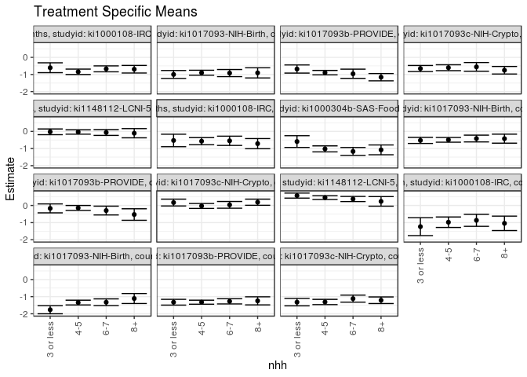

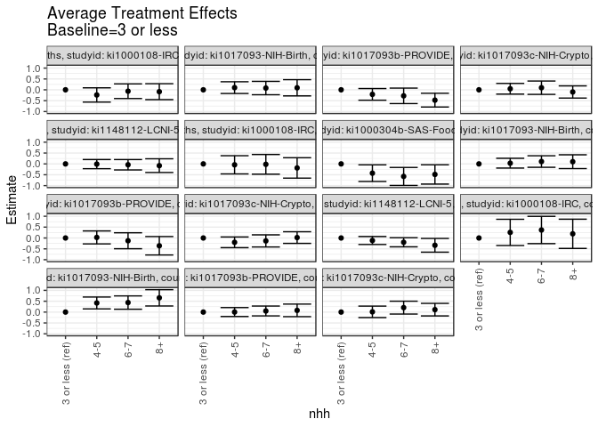

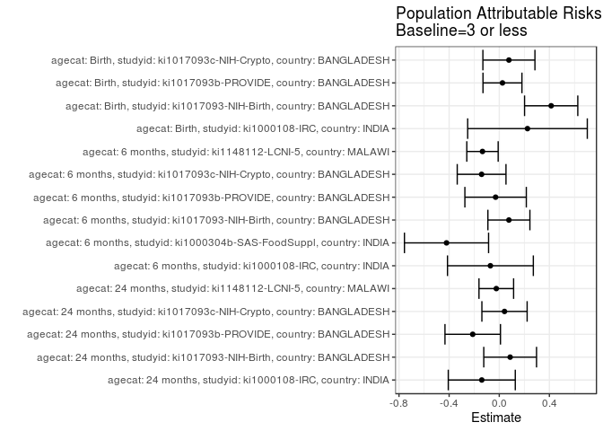

## Results Table

### Parameter: TSM

| agecat | studyid | country | intervention_level | baseline_level | estimate | ci_lower | ci_upper |
| --- | --- | --- | --- | --- | --- | --- | --- |
| Birth | ki1000108-IRC | INDIA | 3 or less | NA | -1.2357988 | -1.7576369 | -0.7139606 |
| Birth | ki1000108-IRC | INDIA | 4-5 | NA | -0.9780233 | -1.2835209 | -0.6725256 |
| Birth | ki1000108-IRC | INDIA | 6-7 | NA | -0.8672804 | -1.2186828 | -0.5158779 |
| Birth | ki1000108-IRC | INDIA | 8+ | NA | -1.0434858 | -1.4642524 | -0.6227193 |
| Birth | ki1017093-NIH-Birth | BANGLADESH | 3 or less | NA | -1.7641511 | -1.9989730 | -1.5293291 |
| Birth | ki1017093-NIH-Birth | BANGLADESH | 4-5 | NA | -1.3446372 | -1.4837215 | -1.2055530 |
| Birth | ki1017093-NIH-Birth | BANGLADESH | 6-7 | NA | -1.3257538 | -1.5217388 | -1.1297688 |
| Birth | ki1017093-NIH-Birth | BANGLADESH | 8+ | NA | -1.1083087 | -1.4003498 | -0.8162676 |
| Birth | ki1017093b-PROVIDE | BANGLADESH | 3 or less | NA | -1.3240286 | -1.4927317 | -1.1553254 |
| Birth | ki1017093b-PROVIDE | BANGLADESH | 4-5 | NA | -1.3227672 | -1.4397599 | -1.2057744 |
| Birth | ki1017093b-PROVIDE | BANGLADESH | 6-7 | NA | -1.2731691 | -1.4250547 | -1.1212836 |
| Birth | ki1017093b-PROVIDE | BANGLADESH | 8+ | NA | -1.2456144 | -1.4813618 | -1.0098669 |
| Birth | ki1017093c-NIH-Crypto | BANGLADESH | 3 or less | NA | -1.3211961 | -1.5363741 | -1.1060181 |
| Birth | ki1017093c-NIH-Crypto | BANGLADESH | 4-5 | NA | -1.3104007 | -1.4638874 | -1.1569141 |
| Birth | ki1017093c-NIH-Crypto | BANGLADESH | 6-7 | NA | -1.1159401 | -1.3202181 | -0.9116620 |
| Birth | ki1017093c-NIH-Crypto | BANGLADESH | 8+ | NA | -1.2092211 | -1.4020410 | -1.0164013 |
| 6 months | ki1000108-IRC | INDIA | 3 or less | NA | -0.5282961 | -0.8926221 | -0.1639700 |
| 6 months | ki1000108-IRC | INDIA | 4-5 | NA | -0.5703593 | -0.7795053 | -0.3612133 |
| 6 months | ki1000108-IRC | INDIA | 6-7 | NA | -0.5484273 | -0.8193836 | -0.2774711 |
| 6 months | ki1000108-IRC | INDIA | 8+ | NA | -0.7137344 | -1.0101432 | -0.4173257 |
| 6 months | ki1000304b-SAS-FoodSuppl | INDIA | 3 or less | NA | -0.5913069 | -0.9335303 | -0.2490835 |
| 6 months | ki1000304b-SAS-FoodSuppl | INDIA | 4-5 | NA | -1.0187187 | -1.1935728 | -0.8438645 |
| 6 months | ki1000304b-SAS-FoodSuppl | INDIA | 6-7 | NA | -1.1682773 | -1.3997725 | -0.9367821 |
| 6 months | ki1000304b-SAS-FoodSuppl | INDIA | 8+ | NA | -1.0766254 | -1.3615319 | -0.7917189 |
| 6 months | ki1017093-NIH-Birth | BANGLADESH | 3 or less | NA | -0.5243036 | -0.7026163 | -0.3459910 |
| 6 months | ki1017093-NIH-Birth | BANGLADESH | 4-5 | NA | -0.4917135 | -0.6296207 | -0.3538064 |
| 6 months | ki1017093-NIH-Birth | BANGLADESH | 6-7 | NA | -0.4154115 | -0.6127525 | -0.2180705 |
| 6 months | ki1017093-NIH-Birth | BANGLADESH | 8+ | NA | -0.4225883 | -0.6855471 | -0.1596295 |
| 6 months | ki1017093b-PROVIDE | BANGLADESH | 3 or less | NA | -0.1699001 | -0.4308168 | 0.0910166 |
| 6 months | ki1017093b-PROVIDE | BANGLADESH | 4-5 | NA | -0.1435432 | -0.2875453 | 0.0004588 |
| 6 months | ki1017093b-PROVIDE | BANGLADESH | 6-7 | NA | -0.2971768 | -0.5552904 | -0.0390632 |
| 6 months | ki1017093b-PROVIDE | BANGLADESH | 8+ | NA | -0.5282991 | -0.8646793 | -0.1919189 |
| 6 months | ki1017093c-NIH-Crypto | BANGLADESH | 3 or less | NA | 0.1706055 | -0.0285310 | 0.3697420 |
| 6 months | ki1017093c-NIH-Crypto | BANGLADESH | 4-5 | NA | -0.0290673 | -0.1724055 | 0.1142709 |
| 6 months | ki1017093c-NIH-Crypto | BANGLADESH | 6-7 | NA | 0.0361273 | -0.1598097 | 0.2320643 |
| 6 months | ki1017093c-NIH-Crypto | BANGLADESH | 8+ | NA | 0.1901925 | 0.0102000 | 0.3701851 |
| 6 months | ki1148112-LCNI-5 | MALAWI | 3 or less | NA | 0.5756116 | 0.4288204 | 0.7224029 |
| 6 months | ki1148112-LCNI-5 | MALAWI | 4-5 | NA | 0.4598785 | 0.3495056 | 0.5702515 |
| 6 months | ki1148112-LCNI-5 | MALAWI | 6-7 | NA | 0.3781748 | 0.2278061 | 0.5285436 |
| 6 months | ki1148112-LCNI-5 | MALAWI | 8+ | NA | 0.2387079 | -0.0413734 | 0.5187893 |
| 24 months | ki1000108-IRC | INDIA | 3 or less | NA | -0.6063219 | -0.8947220 | -0.3179218 |
| 24 months | ki1000108-IRC | INDIA | 4-5 | NA | -0.8438728 | -1.0010581 | -0.6866875 |
| 24 months | ki1000108-IRC | INDIA | 6-7 | NA | -0.6712159 | -0.8447653 | -0.4976666 |
| 24 months | ki1000108-IRC | INDIA | 8+ | NA | -0.6927979 | -0.9132498 | -0.4723460 |
| 24 months | ki1017093-NIH-Birth | BANGLADESH | 3 or less | NA | -0.9984737 | -1.2286006 | -0.7683468 |
| 24 months | ki1017093-NIH-Birth | BANGLADESH | 4-5 | NA | -0.8981220 | -1.0431596 | -0.7530845 |
| 24 months | ki1017093-NIH-Birth | BANGLADESH | 6-7 | NA | -0.9178661 | -1.1244015 | -0.7113307 |
| 24 months | ki1017093-NIH-Birth | BANGLADESH | 8+ | NA | -0.9053154 | -1.2020647 | -0.6085661 |
| 24 months | ki1017093b-PROVIDE | BANGLADESH | 3 or less | NA | -0.6811411 | -0.9186739 | -0.4436082 |
| 24 months | ki1017093b-PROVIDE | BANGLADESH | 4-5 | NA | -0.8919769 | -1.0215744 | -0.7623794 |
| 24 months | ki1017093b-PROVIDE | BANGLADESH | 6-7 | NA | -0.9587542 | -1.2277276 | -0.6897807 |
| 24 months | ki1017093b-PROVIDE | BANGLADESH | 8+ | NA | -1.1574742 | -1.3703788 | -0.9445695 |
| 24 months | ki1017093c-NIH-Crypto | BANGLADESH | 3 or less | NA | -0.6522301 | -0.8285961 | -0.4758641 |
| 24 months | ki1017093c-NIH-Crypto | BANGLADESH | 4-5 | NA | -0.6044671 | -0.7765820 | -0.4323522 |
| 24 months | ki1017093c-NIH-Crypto | BANGLADESH | 6-7 | NA | -0.5562256 | -0.8088418 | -0.3036094 |
| 24 months | ki1017093c-NIH-Crypto | BANGLADESH | 8+ | NA | -0.7521678 | -0.9712931 | -0.5330425 |
| 24 months | ki1148112-LCNI-5 | MALAWI | 3 or less | NA | -0.0241080 | -0.1910640 | 0.1428480 |
| 24 months | ki1148112-LCNI-5 | MALAWI | 4-5 | NA | -0.0339262 | -0.1614603 | 0.0936078 |
| 24 months | ki1148112-LCNI-5 | MALAWI | 6-7 | NA | -0.0635964 | -0.2332471 | 0.1060544 |
| 24 months | ki1148112-LCNI-5 | MALAWI | 8+ | NA | -0.1054398 | -0.3741582 | 0.1632786 |

### Parameter: E(Y)

| agecat | studyid | country | intervention_level | baseline_level | estimate | ci_lower | ci_upper |
| --- | --- | --- | --- | --- | --- | --- | --- |
| Birth | ki1000108-IRC | INDIA | NA | NA | -1.0105831 | -1.1973019 | -0.8238643 |
| Birth | ki1017093-NIH-Birth | BANGLADESH | NA | NA | -1.3499217 | -1.4444634 | -1.2553801 |
| Birth | ki1017093b-PROVIDE | BANGLADESH | NA | NA | -1.2984586 | -1.3752758 | -1.2216415 |
| Birth | ki1017093c-NIH-Crypto | BANGLADESH | NA | NA | -1.2441513 | -1.3281130 | -1.1601897 |
| 6 months | ki1000108-IRC | INDIA | NA | NA | -0.5989297 | -0.7344491 | -0.4634104 |
| 6 months | ki1000304b-SAS-FoodSuppl | INDIA | NA | NA | -1.0121579 | -1.1280429 | -0.8962729 |
| 6 months | ki1017093-NIH-Birth | BANGLADESH | NA | NA | -0.4474038 | -0.5378167 | -0.3569909 |
| 6 months | ki1017093b-PROVIDE | BANGLADESH | NA | NA | -0.1990907 | -0.2817968 | -0.1163845 |
| 6 months | ki1017093c-NIH-Crypto | BANGLADESH | NA | NA | 0.0297622 | -0.0491685 | 0.1086930 |
| 6 months | ki1148112-LCNI-5 | MALAWI | NA | NA | 0.4417647 | 0.3702742 | 0.5132552 |
| 24 months | ki1000108-IRC | INDIA | NA | NA | -0.7458150 | -0.8368180 | -0.6548120 |
| 24 months | ki1017093-NIH-Birth | BANGLADESH | NA | NA | -0.9115790 | -1.0095022 | -0.8136559 |
| 24 months | ki1017093b-PROVIDE | BANGLADESH | NA | NA | -0.8928670 | -0.9755153 | -0.8102187 |
| 24 months | ki1017093c-NIH-Crypto | BANGLADESH | NA | NA | -0.6103502 | -0.7050157 | -0.5156847 |
| 24 months | ki1148112-LCNI-5 | MALAWI | NA | NA | -0.0477867 | -0.1301103 | 0.0345368 |

### Parameter: ATE

| agecat | studyid | country | intervention_level | baseline_level | estimate | ci_lower | ci_upper |
| --- | --- | --- | --- | --- | --- | --- | --- |
| Birth | ki1000108-IRC | INDIA | 3 or less | 3 or less | 0.0000000 | 0.0000000 | 0.0000000 |
| Birth | ki1000108-IRC | INDIA | 4-5 | 3 or less | 0.2577755 | -0.3461929 | 0.8617438 |
| Birth | ki1000108-IRC | INDIA | 6-7 | 3 or less | 0.3685184 | -0.2599519 | 0.9969887 |
| Birth | ki1000108-IRC | INDIA | 8+ | 3 or less | 0.1923129 | -0.4810909 | 0.8657167 |
| Birth | ki1017093-NIH-Birth | BANGLADESH | 3 or less | 3 or less | 0.0000000 | 0.0000000 | 0.0000000 |
| Birth | ki1017093-NIH-Birth | BANGLADESH | 4-5 | 3 or less | 0.4195138 | 0.1459350 | 0.6930926 |
| Birth | ki1017093-NIH-Birth | BANGLADESH | 6-7 | 3 or less | 0.4383973 | 0.1319091 | 0.7448854 |
| Birth | ki1017093-NIH-Birth | BANGLADESH | 8+ | 3 or less | 0.6558423 | 0.2803909 | 1.0312938 |
| Birth | ki1017093b-PROVIDE | BANGLADESH | 3 or less | 3 or less | 0.0000000 | 0.0000000 | 0.0000000 |
| Birth | ki1017093b-PROVIDE | BANGLADESH | 4-5 | 3 or less | 0.0012614 | -0.2040455 | 0.2065683 |
| Birth | ki1017093b-PROVIDE | BANGLADESH | 6-7 | 3 or less | 0.0508594 | -0.1755951 | 0.2773140 |
| Birth | ki1017093b-PROVIDE | BANGLADESH | 8+ | 3 or less | 0.0784142 | -0.2107592 | 0.3675876 |
| Birth | ki1017093c-NIH-Crypto | BANGLADESH | 3 or less | 3 or less | 0.0000000 | 0.0000000 | 0.0000000 |
| Birth | ki1017093c-NIH-Crypto | BANGLADESH | 4-5 | 3 or less | 0.0107954 | -0.2536223 | 0.2752130 |
| Birth | ki1017093c-NIH-Crypto | BANGLADESH | 6-7 | 3 or less | 0.2052560 | -0.0913870 | 0.5018991 |
| Birth | ki1017093c-NIH-Crypto | BANGLADESH | 8+ | 3 or less | 0.1119750 | -0.1770243 | 0.4009742 |
| 6 months | ki1000108-IRC | INDIA | 3 or less | 3 or less | 0.0000000 | 0.0000000 | 0.0000000 |
| 6 months | ki1000108-IRC | INDIA | 4-5 | 3 or less | -0.0420633 | -0.4609158 | 0.3767893 |
| 6 months | ki1000108-IRC | INDIA | 6-7 | 3 or less | -0.0201313 | -0.4737503 | 0.4334878 |
| 6 months | ki1000108-IRC | INDIA | 8+ | 3 or less | -0.1854384 | -0.6554807 | 0.2846039 |
| 6 months | ki1000304b-SAS-FoodSuppl | INDIA | 3 or less | 3 or less | 0.0000000 | 0.0000000 | 0.0000000 |
| 6 months | ki1000304b-SAS-FoodSuppl | INDIA | 4-5 | 3 or less | -0.4274118 | -0.8116869 | -0.0431366 |
| 6 months | ki1000304b-SAS-FoodSuppl | INDIA | 6-7 | 3 or less | -0.5769703 | -0.9909226 | -0.1630181 |
| 6 months | ki1000304b-SAS-FoodSuppl | INDIA | 8+ | 3 or less | -0.4853185 | -0.9301275 | -0.0405095 |
| 6 months | ki1017093-NIH-Birth | BANGLADESH | 3 or less | 3 or less | 0.0000000 | 0.0000000 | 0.0000000 |
| 6 months | ki1017093-NIH-Birth | BANGLADESH | 4-5 | 3 or less | 0.0325901 | -0.1927853 | 0.2579655 |
| 6 months | ki1017093-NIH-Birth | BANGLADESH | 6-7 | 3 or less | 0.1088921 | -0.1566408 | 0.3744251 |
| 6 months | ki1017093-NIH-Birth | BANGLADESH | 8+ | 3 or less | 0.1017153 | -0.2157478 | 0.4191785 |
| 6 months | ki1017093b-PROVIDE | BANGLADESH | 3 or less | 3 or less | 0.0000000 | 0.0000000 | 0.0000000 |
| 6 months | ki1017093b-PROVIDE | BANGLADESH | 4-5 | 3 or less | 0.0263569 | -0.2717148 | 0.3244286 |
| 6 months | ki1017093b-PROVIDE | BANGLADESH | 6-7 | 3 or less | -0.1272767 | -0.4943867 | 0.2398334 |
| 6 months | ki1017093b-PROVIDE | BANGLADESH | 8+ | 3 or less | -0.3583990 | -0.7837362 | 0.0669383 |
| 6 months | ki1017093c-NIH-Crypto | BANGLADESH | 3 or less | 3 or less | 0.0000000 | 0.0000000 | 0.0000000 |
| 6 months | ki1017093c-NIH-Crypto | BANGLADESH | 4-5 | 3 or less | -0.1996728 | -0.4452197 | 0.0458742 |
| 6 months | ki1017093c-NIH-Crypto | BANGLADESH | 6-7 | 3 or less | -0.1344781 | -0.4136514 | 0.1446951 |
| 6 months | ki1017093c-NIH-Crypto | BANGLADESH | 8+ | 3 or less | 0.0195871 | -0.2490321 | 0.2882062 |
| 6 months | ki1148112-LCNI-5 | MALAWI | 3 or less | 3 or less | 0.0000000 | 0.0000000 | 0.0000000 |
| 6 months | ki1148112-LCNI-5 | MALAWI | 4-5 | 3 or less | -0.1157331 | -0.2990704 | 0.0676042 |
| 6 months | ki1148112-LCNI-5 | MALAWI | 6-7 | 3 or less | -0.1974368 | -0.4071122 | 0.0122386 |
| 6 months | ki1148112-LCNI-5 | MALAWI | 8+ | 3 or less | -0.3369037 | -0.6529132 | -0.0208942 |
| 24 months | ki1000108-IRC | INDIA | 3 or less | 3 or less | 0.0000000 | 0.0000000 | 0.0000000 |
| 24 months | ki1000108-IRC | INDIA | 4-5 | 3 or less | -0.2375509 | -0.5657050 | 0.0906032 |
| 24 months | ki1000108-IRC | INDIA | 6-7 | 3 or less | -0.0648940 | -0.4021734 | 0.2723853 |
| 24 months | ki1000108-IRC | INDIA | 8+ | 3 or less | -0.0864760 | -0.4527202 | 0.2797682 |
| 24 months | ki1017093-NIH-Birth | BANGLADESH | 3 or less | 3 or less | 0.0000000 | 0.0000000 | 0.0000000 |
| 24 months | ki1017093-NIH-Birth | BANGLADESH | 4-5 | 3 or less | 0.1003517 | -0.1697856 | 0.3704890 |
| 24 months | ki1017093-NIH-Birth | BANGLADESH | 6-7 | 3 or less | 0.0806077 | -0.2273161 | 0.3885314 |
| 24 months | ki1017093-NIH-Birth | BANGLADESH | 8+ | 3 or less | 0.0931583 | -0.2804895 | 0.4668061 |
| 24 months | ki1017093b-PROVIDE | BANGLADESH | 3 or less | 3 or less | 0.0000000 | 0.0000000 | 0.0000000 |
| 24 months | ki1017093b-PROVIDE | BANGLADESH | 4-5 | 3 or less | -0.2108358 | -0.4793502 | 0.0576785 |
| 24 months | ki1017093b-PROVIDE | BANGLADESH | 6-7 | 3 or less | -0.2776131 | -0.6343480 | 0.0791219 |
| 24 months | ki1017093b-PROVIDE | BANGLADESH | 8+ | 3 or less | -0.4763331 | -0.7936735 | -0.1589927 |
| 24 months | ki1017093c-NIH-Crypto | BANGLADESH | 3 or less | 3 or less | 0.0000000 | 0.0000000 | 0.0000000 |
| 24 months | ki1017093c-NIH-Crypto | BANGLADESH | 4-5 | 3 or less | 0.0477630 | -0.1983012 | 0.2938272 |
| 24 months | ki1017093c-NIH-Crypto | BANGLADESH | 6-7 | 3 or less | 0.0960045 | -0.2117872 | 0.4037962 |
| 24 months | ki1017093c-NIH-Crypto | BANGLADESH | 8+ | 3 or less | -0.0999377 | -0.3811379 | 0.1812625 |
| 24 months | ki1148112-LCNI-5 | MALAWI | 3 or less | 3 or less | 0.0000000 | 0.0000000 | 0.0000000 |
| 24 months | ki1148112-LCNI-5 | MALAWI | 4-5 | 3 or less | -0.0098183 | -0.2203531 | 0.2007166 |
| 24 months | ki1148112-LCNI-5 | MALAWI | 6-7 | 3 or less | -0.0394884 | -0.2778523 | 0.1988755 |
| 24 months | ki1148112-LCNI-5 | MALAWI | 8+ | 3 or less | -0.0813318 | -0.3968504 | 0.2341867 |

### Parameter: PAR

| agecat | studyid | country | intervention_level | baseline_level | estimate | ci_lower | ci_upper |
| --- | --- | --- | --- | --- | --- | --- | --- |
| Birth | ki1000108-IRC | INDIA | 3 or less | NA | 0.2252157 | -0.2520197 | 0.7024511 |
| Birth | ki1017093-NIH-Birth | BANGLADESH | 3 or less | NA | 0.4142293 | 0.2018490 | 0.6266096 |
| Birth | ki1017093b-PROVIDE | BANGLADESH | 3 or less | NA | 0.0255699 | -0.1297906 | 0.1809305 |
| Birth | ki1017093c-NIH-Crypto | BANGLADESH | 3 or less | NA | 0.0770448 | -0.1305665 | 0.2846560 |
| 6 months | ki1000108-IRC | INDIA | 3 or less | NA | -0.0706337 | -0.4131130 | 0.2718456 |
| 6 months | ki1000304b-SAS-FoodSuppl | INDIA | 3 or less | NA | -0.4208510 | -0.7565062 | -0.0851957 |
| 6 months | ki1017093-NIH-Birth | BANGLADESH | 3 or less | NA | 0.0768999 | -0.0906968 | 0.2444965 |
| 6 months | ki1017093b-PROVIDE | BANGLADESH | 3 or less | NA | -0.0291905 | -0.2742726 | 0.2158915 |
| 6 months | ki1017093c-NIH-Crypto | BANGLADESH | 3 or less | NA | -0.1408432 | -0.3353244 | 0.0536379 |
| 6 months | ki1148112-LCNI-5 | MALAWI | 3 or less | NA | -0.1338469 | -0.2589754 | -0.0087185 |
| 24 months | ki1000108-IRC | INDIA | 3 or less | NA | -0.1394931 | -0.4068513 | 0.1278651 |
| 24 months | ki1017093-NIH-Birth | BANGLADESH | 3 or less | NA | 0.0868947 | -0.1235605 | 0.2973499 |
| 24 months | ki1017093b-PROVIDE | BANGLADESH | 3 or less | NA | -0.2117259 | -0.4331015 | 0.0096496 |
| 24 months | ki1017093c-NIH-Crypto | BANGLADESH | 3 or less | NA | 0.0418799 | -0.1386252 | 0.2223850 |
| 24 months | ki1148112-LCNI-5 | MALAWI | 3 or less | NA | -0.0236788 | -0.1618021 | 0.1144446 |